# Bootstrap y test de permutación: soluciones de la práctica en R

**Bootstrap y test de permutación:**  
soluciones de la práctica en `R`

[figure not shown]

Marta Coronado Zamora Octubre 2026

> Las respuestas a las preguntas aparecen en recuadros azules. Los valores numéricos se han obtenido con `set.seed(2026)`: si repites el remuestreo sin semilla, tus números pueden variar ligeramente.

# Bootstrap

## 🐒🧠 Centros del lenguaje en chimpancés

#### **Paso 1: leer los datos**

```r
chimp <- read.csv("https://raw.githubusercontent.com/marta-coronado/biostatistics-uab/refs/heads/main/P/2/chap19e2ChimpBrains.csv", header = TRUE)
```

```r
head(chimp)
```

```
##    chimpName sex asymmetryScore
## 1     Austin   M           0.30
## 2 Carmichael   M           0.16
## 3      Chuck   M          -0.24
## 4      Dobbs   M          -0.25
## 5     Donald   M           0.36
## 6      Hoboh   M           0.17
```

```r
nrow(chimp)
```

```
## [1] 20
```

```r
chimp$chimpName <- as.factor(chimp$chimpName)
```

#### **Paso 2: crea un histograma**

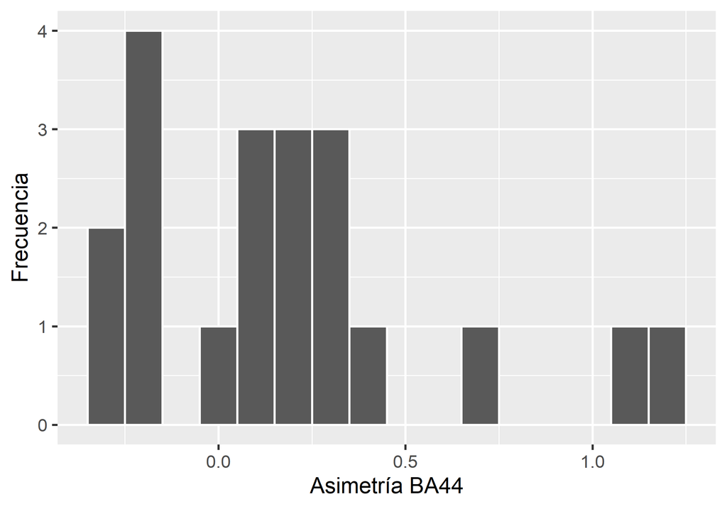

```r
ggplot(chimp, aes(x = asymmetryScore)) +
  geom_histogram(binwidth = 0.1, color = "white") +
  labs(x = "Asimetría BA44", y = "Frecuencia")
```

La distribución es **asimétrica a la derecha**: la mayoría de valores se concentran entre −0.3 y 0.4, y hay unos pocos chimpancés con valores muy altos (0.71, 1.12, 1.19). Con solo 20 datos y esta cola derecha, **no es prudente asumir normalidad**. Por eso usamos la mediana (robusta a valores extremos) y el bootstrap (que no asume ninguna distribución).

#### **Paso 3: cálculo de la estimación a partir de los datos**

```r
sample_estimate <- median(chimp$asymmetryScore)
sample_estimate
```

```
## [1] 0.14
```

#### **Paso 4: re-muestreo de nuestros datos (con reemplazo) para generar una réplica bootstrap**

```r
resampled_chimps <- chimp  %>%
  sample_n(size = nrow(chimp), replace = TRUE)
```

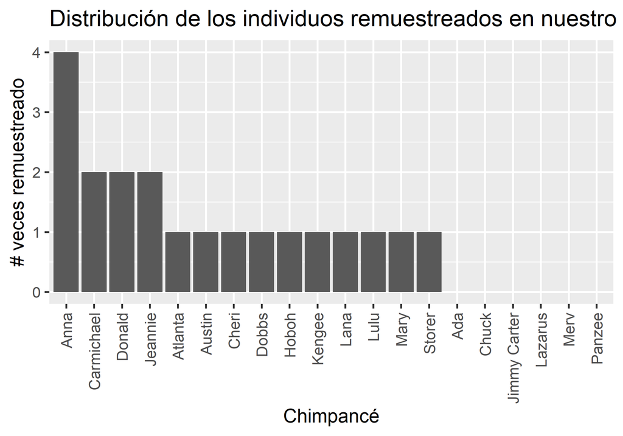

```r
resampled_chimps                   %>%
  group_by(chimpName, .drop = FALSE) %>%
  tally(sort = TRUE)               %>%
  mutate(id = fct_reorder(chimpName, n, .desc = TRUE)) %>%
  ggplot(aes(x = id, y = n)) +
  geom_col() +
  labs(title = "Distribución de los individuos remuestreados en nuestro bootstrap",
       x = "Chimpancé", y = "# veces remuestreado") +
  theme(axis.text.x = element_text(angle = 90, hjust = 1, vjust = 0.5))
```

Algunos chimpancés aparecen 2 o más veces y otros tienen 0: el remuestreo con reemplazo ha funcionado. (En promedio, cada réplica bootstrap deja fuera ~37% de los individuos originales.)

#### **Paso 5: estimación a partir de los datos remuestreados**

```r
median(resampled_chimps$asymmetryScore)
```

```
## [1] 0.16
```

En general **no coincide** con la mediana original (0.14). La réplica bootstrap es una muestra distinta (unos individuos repetidos, otros ausentes), así que su mediana varía por azar. Esa variación entre réplicas es precisamente lo que usamos para medir la incertidumbre de la estimación.

#### **Paso 6: repetir el proceso 10.000 veces**

```r
many_resampled_chimps <- chimp  %>%
  rep_sample_n(size = nrow(chimp), replace = TRUE, reps = 10000)

# View(many_resampled_chimps)
head(many_resampled_chimps)
```

```
## # A tibble: 6 × 4
## # Groups:   replicate [1]
##   replicate chimpName sex   asymmetryScore
##       <int> <fct>     <chr>          <dbl>
## 1         1 Donald    M               0.36
## 2         1 Kengee    F               0.01
## 3         1 Chuck     M              -0.24
## 4         1 Anna      F               0.09
## 5         1 Chuck     M              -0.24
## 6         1 Chuck     M              -0.24
```

```r
nrow(many_resampled_chimps)
```

```
## [1] 200000
```

Tiene **200.000 filas** = 20 chimpancés × 10.000 réplicas. La columna `replicate` (de 1 a 10.000) indica a qué réplica bootstrap pertenece cada fila.

#### **Paso 7: calcular la mediana de cada réplica**

```r
chimp_boot <- many_resampled_chimps %>%
  group_by(replicate) %>%
  summarize(median_asymmetry = median(asymmetryScore))

head(chimp_boot)
```

```
## # A tibble: 6 × 2
##   replicate median_asymmetry
##       <int>            <dbl>
## 1         1            0.2
## 2         2            0.205
## 3         3           -0.075
## 4         4            0.24
## 5         5            0.125
## 6         6            0.125
```

```r
nrow(chimp_boot)
```

```
## [1] 10000
```

`chimp_boot` tiene **10.000 filas**: una mediana por cada réplica bootstrap.

#### **Paso 8: visualización de la distribución bootstrap**

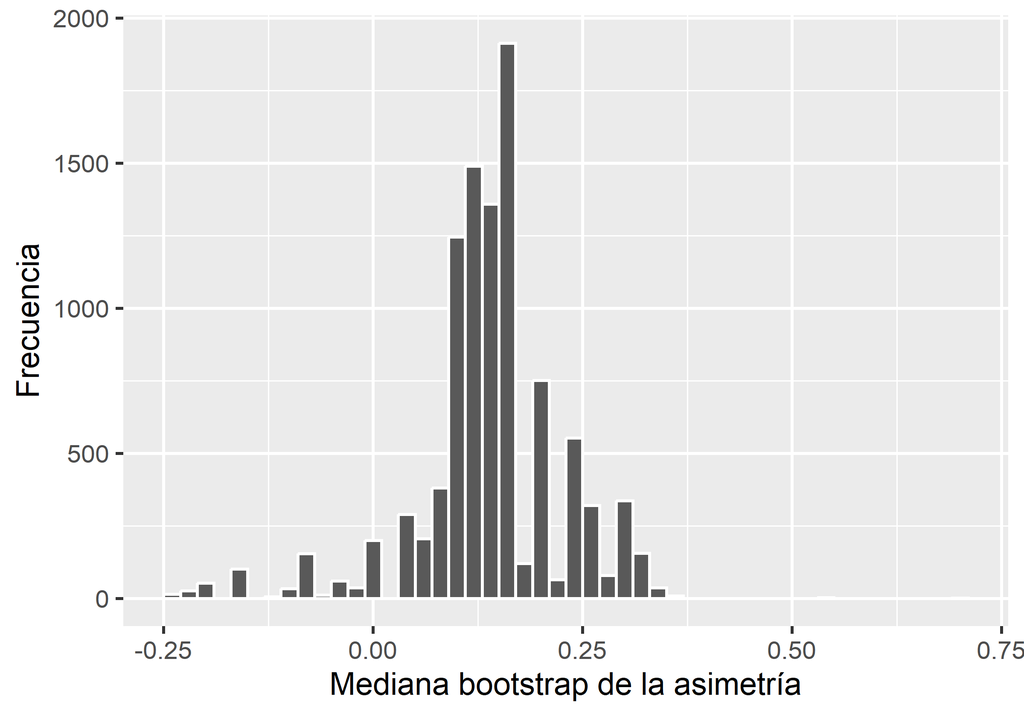

```r
boot_hist <- ggplot(chimp_boot, aes(x = median_asymmetry)) +
  geom_histogram(binwidth = 0.02, color = "white") +
  labs(x = "Mediana bootstrap de la asimetría", y = "Frecuencia")

boot_hist
```

El histograma es muy “a saltos”: con n = 20 la mediana es la media de los valores 10º y 11º ordenados, y solo puede tomar un número limitado de valores distintos. Es una característica de la mediana bootstrap con muestras pequeñas, no un error.

#### **Paso 9: intervalo de confianza bootstrap**

```r
chimp_boot_CI <- chimp_boot %>%
  reframe(CI               = c("lower 95", "upper 95"),
          median_asymmetry = quantile(median_asymmetry, probs = c(0.025, 0.975)))

chimp_boot_CI
```

```
## # A tibble: 2 × 2
##   CI       median_asymmetry
##   <chr>               <dbl>
## 1 lower 95           -0.075
## 2 upper 95            0.31
```

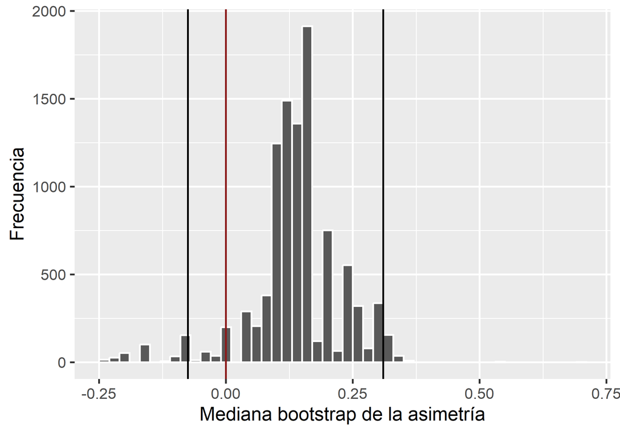

```r
boot_hist +
  geom_vline(xintercept = pull(chimp_boot_CI, median_asymmetry)) +
  geom_vline(xintercept = 0, color = "firebrick4")
```

**Interpretación:** si repitiéramos el estudio muchas veces y construyéramos un IC bootstrap del 95% en cada ocasión, aproximadamente el 95% de esos intervalos contendrían la verdadera mediana poblacional. El 95% se refiere al **procedimiento**: para *este* intervalo concreto, la mediana poblacional está dentro o no lo está; no decimos que haya un 95% de probabilidad.

**Conclusión:** a partir del bootstrap con **10.000** réplicas, estimamos que la mediana de asimetría del Área de Brodmann 44 en chimpancés se encuentra entre **-0.075** y **0.31** con un **95%** de confianza. Dado que el intervalo incluye 0, **no** hay evidencia estadística de asimetría lateralizada (no rechazamos $H_0$ al 5%, dos colas).

**Reflexión:** que el IC incluya 0 **no demuestra que no haya asimetría**; solo indica que *no tenemos evidencia suficiente* para afirmarla. El intervalo es compatible tanto con ausencia de asimetría como con una asimetría positiva moderada (hasta ~0.31). Con solo 20 chimpancés hay que ser prudente: el IC bootstrap por percentiles tiende a ser **demasiado estrecho** (cobertura real < 95%) con muestras pequeñas, y con la mediana la distribución bootstrap es muy discreta. Lo ideal sería aumentar el tamaño muestral o usar métodos corregidos (p. ej., BCa).

# Test de permutación

## 🐒🐒 Ejemplo: ¿son igual de asimétricos los chimpancés y los bonobos?

#### **Paso 1: crear el conjunto de datos**

```r
bonobo <- data.frame(
  species        = "Bonobo",
  asymmetryScore = c(0.71, 0.53, 0.60, 0.38, 0.84, 0.55, 0.05, 0.69, 0.78, 0.50,
                     0.58, 1.04, 0.44, 0.67, 0.53, 0.81, 0.21, 0.59, 0.77, 0.54)
)

monkeys <- chimp %>%
  transmute(species = "Chimpanzee", asymmetryScore = asymmetryScore) %>%
  bind_rows(bonobo)

head(monkeys)
```

```
##      species asymmetryScore
## 1 Chimpanzee           0.30
## 2 Chimpanzee           0.16
## 3 Chimpanzee          -0.24
## 4 Chimpanzee          -0.25
## 5 Chimpanzee           0.36
## 6 Chimpanzee           0.17
```

#### **Paso 2: revisar los datos**

```r
monkeys_summary <- monkeys %>%
  group_by(species) %>%
  summarize(n    = n(),
            mean = mean(asymmetryScore))

monkeys_summary
```

```
## # A tibble: 2 × 3
##   species        n  mean
##   <chr>      <int> <dbl>
## 1 Bonobo        20 0.590
## 2 Chimpanzee    20 0.192
```

Hay 20 individuos de cada especie. Los **bonobos** parecen más asimétricos (más lateralizados hacia la izquierda): su media (~0.59) es claramente mayor que la de los chimpancés (~0.19). Podría deberse al azar con muestras de 20, y eso es justamente lo que evaluaremos con el test de permutación.

#### **Paso 3: visualizar con un boxplot**

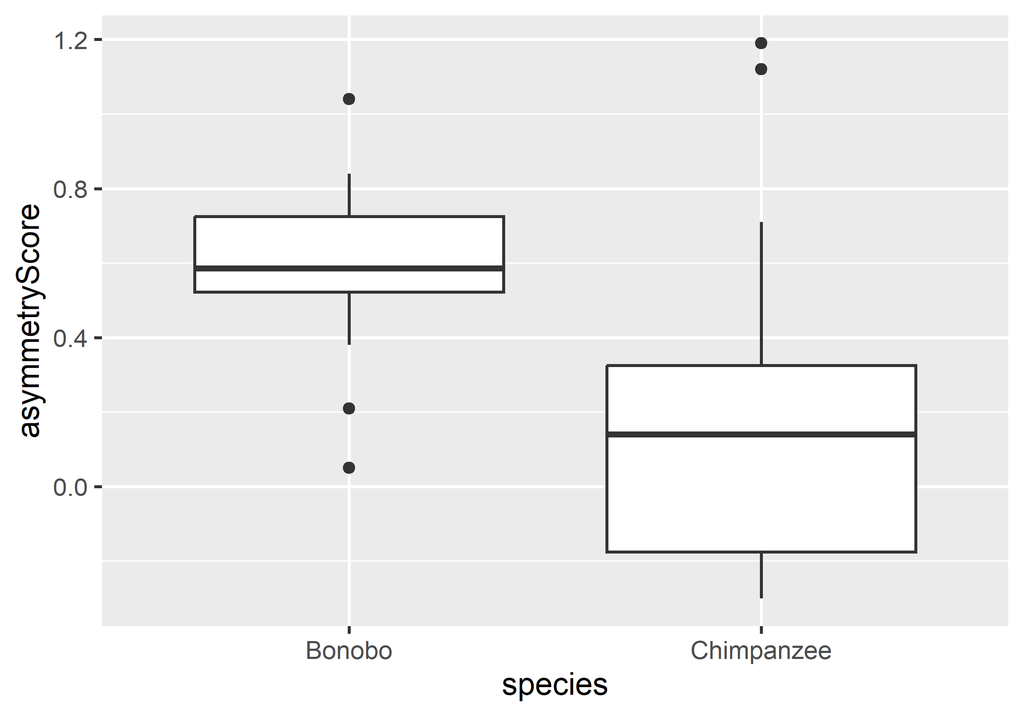

```r
ggplot(monkeys, aes(x = species, y = asymmetryScore)) +
  geom_boxplot()
```

#### **Paso 4: calcular el estadístico observado**

```r
baseline_difference <- monkeys_summary$mean[monkeys_summary$species == "Chimpanzee"] -
                       monkeys_summary$mean[monkeys_summary$species == "Bonobo"]
baseline_difference
```

```
## [1] -0.399
```

La diferencia es **negativa** (-0.399): en promedio, los chimpancés tienen una asimetría menor que los bonobos, es decir, los bonobos (ficticios) están más lateralizados hacia el hemisferio izquierdo.

#### **Paso 5: generar la distribución nula con permutaciones (10000)**

```r
perm <- monkeys %>%
  specify(asymmetryScore ~ species) %>%
  hypothesize(null = "independence") %>%
  generate(reps = 10000, type = "permute") %>%
  calculate(stat = "diff in means", order = c("Chimpanzee", "Bonobo"))

head(perm)
```

```
## Response: asymmetryScore (numeric)
## Explanatory: species (factor)
## Null Hypothe...
## # A tibble: 6 × 2
##   replicate    stat
##       <int>   <dbl>
## 1         1  0.045
## 2         2  0.187
## 3         3 -0.0260
## 4         4 -0.068
## 5         5  0.0250
## 6         6 -0.15
```

```r
nrow(perm)
```

```
## [1] 10000
```

`perm` tiene **10.000 filas**, una por permutación. La columna `stat` contiene la **diferencia de medias (Chimpanzee − Bonobo)** calculada tras mezclar al azar las etiquetas de especie, es decir, diferencias que esperaríamos si $H_0$ fuera cierta.

#### **Paso 6: visualizar la distribución nula y dónde cae nuestro valor observado**

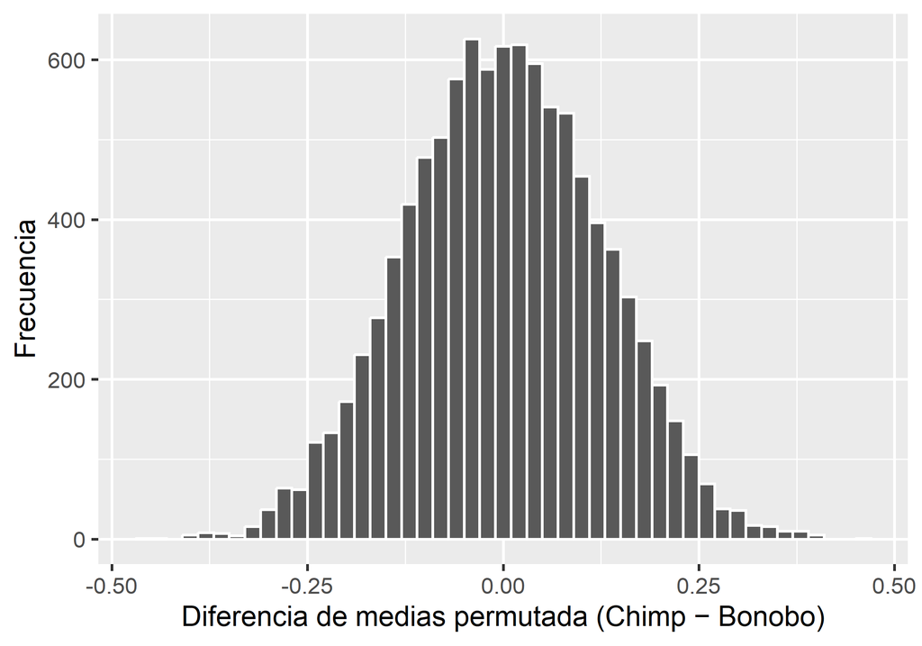

```r
diffs_histogram_plot <- ggplot(perm, aes(x = stat)) +
  geom_histogram(binwidth = 0.02, color = "white") +
  labs(x = "Diferencia de medias permutada (Chimp − Bonobo)", y = "Frecuencia")

diffs_histogram_plot
```

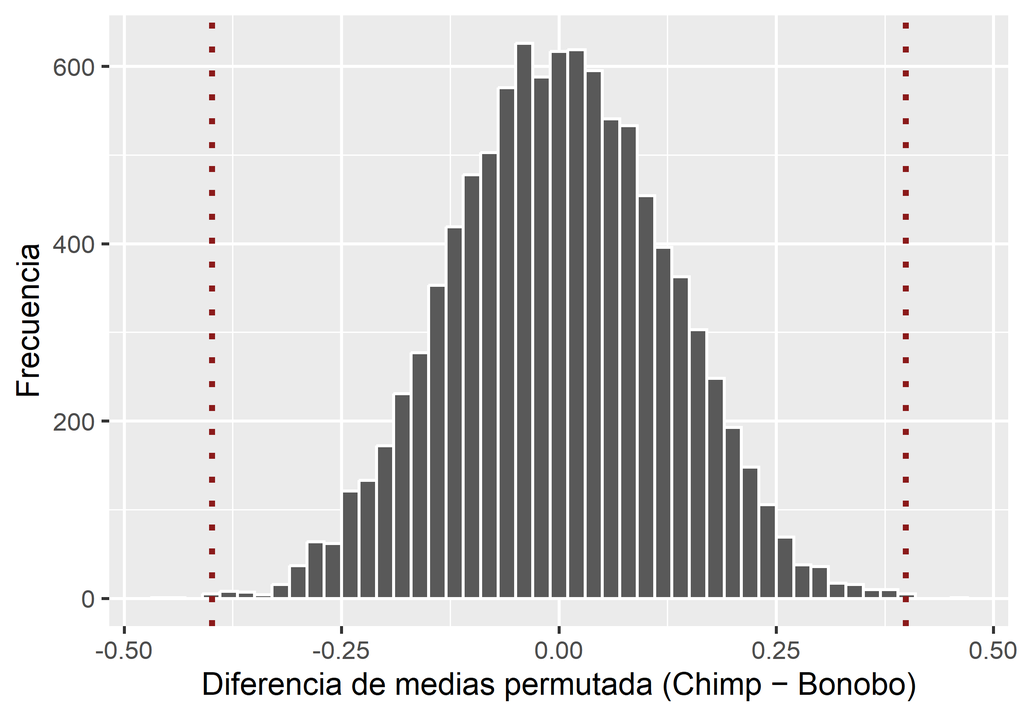

```r
g1 <- diffs_histogram_plot +
  geom_vline(xintercept = c(baseline_difference, -baseline_difference),
             linetype   = "dotted",
             color      = "firebrick4",
             linewidth  = 1)

g1
```

Sí, nuestro valor observado (-0.399) cae en el **extremo** de la distribución nula: muy pocas permutaciones dan una diferencia tan grande en valor absoluto. Esto sugiere que una diferencia así sería muy poco probable si no hubiera diferencia real entre especies.

#### **Paso 7: calcular el p-valor de dos colas**

```r
n_sims <- nrow(perm)

p_value <- perm %>%
  filter(abs(stat) >= abs(baseline_difference)) %>%
  nrow() / n_sims

p_value
```

```
## [1] 7e-04
```

```r
# Alternativa con infer:
perm %>% get_p_value(obs_stat = baseline_difference, direction = "two-sided")
```

```
## # A tibble: 1 × 1
##   p_value
##     <dbl>
## 1  0.0008
```